# Data science per psicologi - demo 21.01

Corrado Caudek

2022-04-21

```r
suppressPackageStartupMessages({
  library("here")
  library("tidyverse")
  library("bayesplot")
  library("rstan")
  library("cmdstanr")
  library("bayesrules")
})

rstan_options(auto_write = TRUE) # avoid recompilation of models
options(mc.cores = parallel::detectCores()) # parallelize across all CPUs
Sys.setenv(LOCAL_CPPFLAGS = "-march=native") # improve execution time

theme_set(bayesplot::theme_default(base_size = 12))
bayesplot::color_scheme_set("gray")
set.seed(84735)

knitr::opts_chunk$set(
  collapse = TRUE,
  tidy = 'styler',
  fig.width = 6,
  fig.asp = 0.618 # 1 / phi
)
```

# Sintesi della distribuzione a posteriori

## Esperimento di Milgram

Nell’esperimento di Milgram (1963), 26 partecipanti su 40 hanno inflitto delle scosse elettriche della massima intensità ai loro compagni – non sapevano in realtà che le scosse fossero solo apparenti, non reali.

Per analizzare questi dati, nel testo *Bayes rules!* si impone una Beta(1, 10) quale distribuzione a priori su $\theta$ (probabilità ignota di infliggere una scossa).

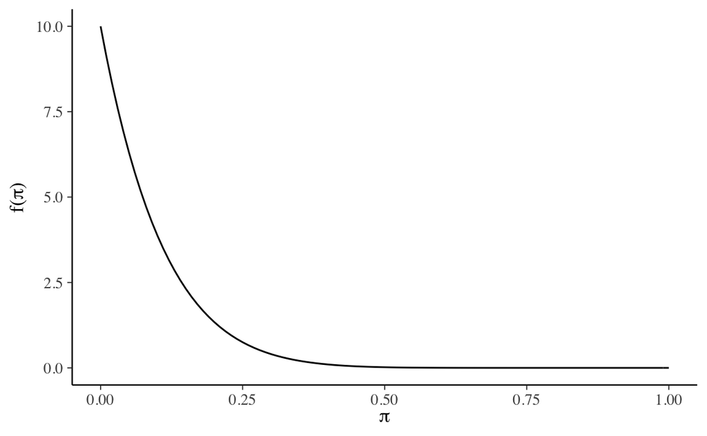

```r
bayesrules::plot_beta(1, 10)
```

Questa scelta della distribuzione a priori ci consente di affrontare il problema all’interno dello schema beta-binomiale. In tali circostanze è facile trovare la distribuzione a posteriori.

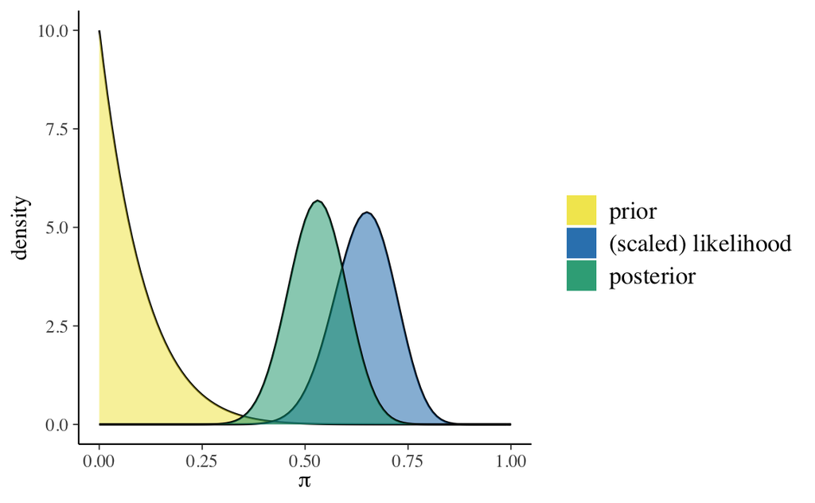

```r
plot_beta_binomial(alpha = 1, beta = 10, y = 26, n = 40)
```

I valori numerici si ottengono nel modo seguente.

```r
summarize_beta_binomial(alpha = 1, beta = 10, y = 26, n = 40)
```

```
##       model alpha beta       mean      mode         var         sd
## 1     prior     1   10 0.09090909 0.0000000 0.006887052 0.08298827
## 2 posterior    27   24 0.52941176 0.5306122 0.004791057 0.06921746
```

La media della distribuzione Beta è $\mathbb{E}(\pi) = \alpha / (\alpha + \beta)$.

```r
27 / (27 + 24)
```

```
## [1] 0.5294118
```

La moda è

$$\mbox{Mo}(\pi) = {\displaystyle {\frac {\alpha -1}{\alpha +\beta -2}}}$$
ovvero

```r
(27 - 1) / (27 + 24 - 2)
```

```
## [1] 0.5306122
```

La varianza è

$$\operatorname{var}(X) = \operatorname{E}[(X - \mu)^2] = \frac{\alpha
\beta}{(\alpha + \beta)^2(\alpha + \beta + 1)}$$

ovvero

```r
(27 * 24) / ((27 + 24)^2 * (27 + 24 + 1))
```

```
## [1] 0.004791057
```

### Soluzione con Stan

Svolgiamo ora l’analisi con Stan.

I dati nella forma adeguata per essere letti in Stan sono i seguenti.

```r
data_list <- list(
  N = 40,
  y = c(rep(1, 26), rep(0, 14))
)
data_list
```

```
## $N
## [1] 40
##
## $y
##  [1] 1 1 1 1 1 1 1 1 1 1 1 1 1 1 1 1 1 1 1 1 1 1 1 1 1 1 0 0 0 0 0 0 0 0 0 0 0 0
## [39] 0 0
```

Specifico il modello.

```r
model_string <- "
data {
  int<lower=0> N;
  array[N] int<lower=0, upper=1> y;
}
parameters {
  real<lower=0, upper=1> theta;
}
model {
  theta ~ beta(1, 10);
  y ~ bernoulli(theta);
}
"
```

Compilo il modello.

```r
writeLines(model_string, con = "code/oneprop_4.stan")
file <- file.path("code", "oneprop_4.stan")
mod <- cmdstan_model(file)
```

Eseguo il campionamento MCMC.

```r
fit <- mod$sample(
  data = data_list,
  iter_sampling = 10000L,
  iter_warmup = 2000L,
  seed = 84735,
  chains = 4L,
  refresh = 0,
  thin = 1
)
## Running MCMC with 4 chains, at most 8 in parallel...
##
## Chain 1 finished in 0.1 seconds.
## Chain 2 finished in 0.1 seconds.
## Chain 3 finished in 0.1 seconds.
## Chain 4 finished in 0.1 seconds.
##
## All 4 chains finished successfully.
## Mean chain execution time: 0.1 seconds.
## Total execution time: 0.3 seconds.
```

Rappresento graficamente la distribuzione a posteriori.

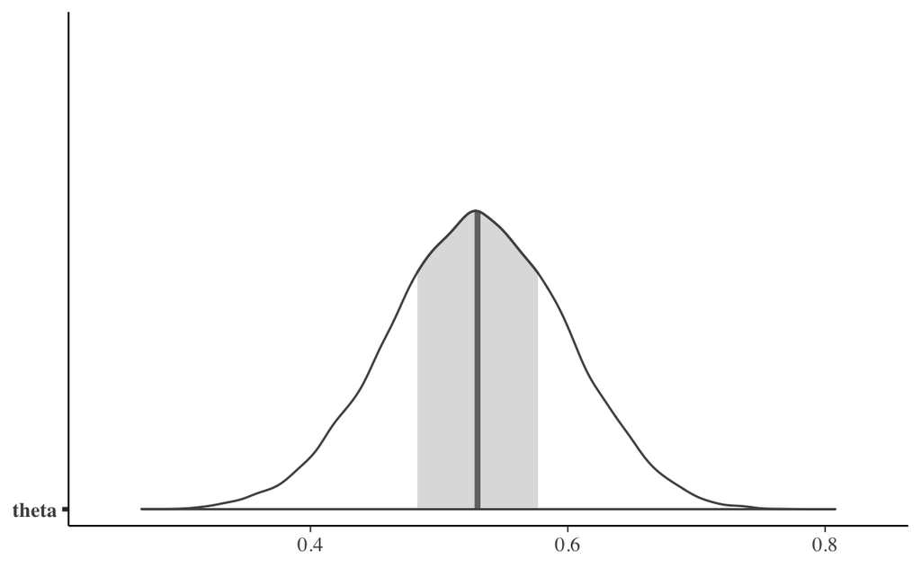

```r
fit_stanfit <- rstan::read_stan_csv(fit$output_files())
posterior <- as.matrix(fit_stanfit)
mcmc_areas(posterior, pars = c("theta"))
```

Una sintesi della distribuzione a posteriori si trova nel modo seguente.

```r
fit$summary(c("theta"))
```

```
## # A tibble: 1 × 10
##   variable  mean median     sd    mad    q5   q95  rhat ess_bulk ess_tail
##   <chr>    <dbl>  <dbl>  <dbl>  <dbl> <dbl> <dbl> <dbl>    <dbl>    <dbl>
## 1 theta    0.530  0.530 0.0688 0.0694 0.415 0.643  1.00   14991.   17077.
```

Calcolo l’intervallo di credibilità al 95%. La scelta dell’95% è del tutto arbitraria.

```r
out <- rstantools::posterior_interval(
  as.matrix(fit_stanfit),
  prob = 0.95
)
out
```

```
##              2.5%       97.5%
## theta   0.3933767   0.6623895
## lp__  -37.7855075 -35.2627000
```

Con l’istruzione seguente trovo l’intervallo di massima densità (HDI).

```r
stanfit <- rstan::read_stan_csv(fit$output_files())
bayestestR::hdi(stanfit, ci = 0.95)
## Highest Density Interval
##
## Parameter |      95% HDI
## ------------------------
## theta     | [0.40, 0.66]
```

È anche esprimere la stessa incertezza scegliendo un diverso livello di probabilità. Per esempio

```r
out <- rstantools::posterior_interval(
  as.matrix(fit_stanfit),
  prob = 0.75
)
out
```

```
##           12.5%       87.5%
## theta   0.45004   0.6088679
## lp__  -36.44831 -35.2741000
```

oppure

```r
stanfit <- rstan::read_stan_csv(fit$output_files())
bayestestR::hdi(stanfit, ci = 0.75)
## Highest Density Interval
##
## Parameter |      75% HDI
## ------------------------
## theta     | [0.45, 0.61]
```

### Distribuzione a priori non coniugata

Considero ora un esempio in cui non è possibile usare lo schema beta-binomiale.

Supponiamo che la distribuzione a priori per $\theta$ sia una $\mathcal{N}(0, 0.12)$.

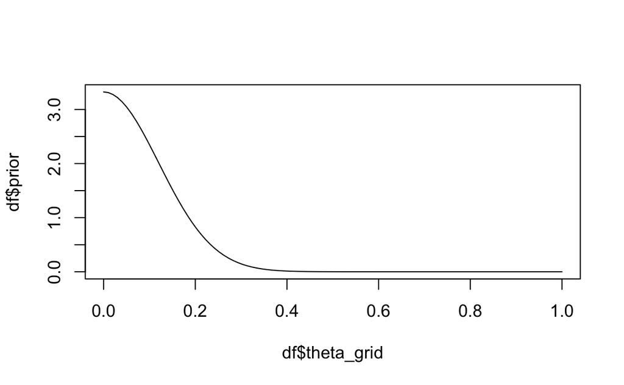

```r
ngrid <- 100
theta_grid <- seq(0, 1, length.out = ngrid)
prior <- dnorm(theta_grid, mean = 0, sd = 0.12)
df <- data.frame(
  theta_grid = theta_grid, prior = prior
)

plot(df$theta_grid, df$prior, type = "l")
```

Con una $\mathcal{N}(0, 0.12)$, le credenze descritte dalla distribuzione a priori sono molto simili a quelle descritte da una Beta(1, 10), anche se non identiche.

Tutte le altre caratteristiche del problema restano uguali al caso discusso sopra.

Specifico dunque il modello in Stan.

```r
model2_string <- "
data {
  int<lower=0> N;
  array[N] int<lower=0, upper=1> y;
}
parameters {
  real<lower=0, upper=1> theta;
}
model {
  theta ~ normal(0, 0.12);
  y ~ bernoulli(theta);
}
"
```

Compilo il modello.

```r
writeLines(model2_string, con = "code/oneprop_5.stan")
file2 <- file.path("code", "oneprop_5.stan")
mod2 <- cmdstan_model(file2)
```

Eseguo il campionamento MCMC.

```r
fit2 <- mod2$sample(
  data = data_list,
  iter_sampling = 10000L,
  iter_warmup = 2000L,
  seed = 84735,
  chains = 4L,
  refresh = 0
)
## Running MCMC with 4 chains, at most 8 in parallel...
##
## Chain 1 finished in 0.1 seconds.
## Chain 2 finished in 0.1 seconds.
## Chain 3 finished in 0.1 seconds.
## Chain 4 finished in 0.1 seconds.
##
## All 4 chains finished successfully.
## Mean chain execution time: 0.1 seconds.
## Total execution time: 0.2 seconds.
```

Rappresento graficamente la distribuzione a posteriori.

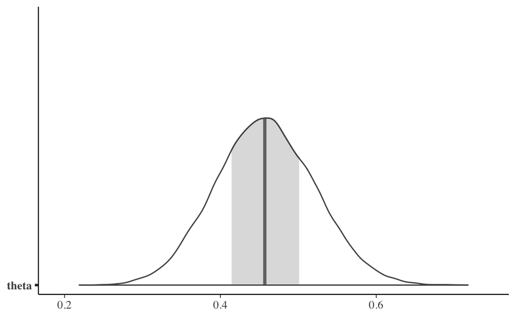

```r
fit2_stanfit <- rstan::read_stan_csv(fit2$output_files())
posterior2 <- as.matrix(fit2_stanfit)
mcmc_areas(posterior2, pars = c("theta"))
```

Una sintesi della distribuzione a posteriori si trova nel modo seguente.

```r
fit2$summary(c("theta"))
```

```
## # A tibble: 1 × 10
##   variable  mean median     sd    mad    q5   q95  rhat ess_bulk ess_tail
##   <chr>    <dbl>  <dbl>  <dbl>  <dbl> <dbl> <dbl> <dbl>    <dbl>    <dbl>
## 1 theta    0.458  0.457 0.0636 0.0641 0.354 0.564  1.00   14328.   19387.
```

```r
out2 <- rstantools::posterior_interval(
  as.matrix(fit2_stanfit),
  prob = 0.95
)
out2
```

```
##              2.5%       97.5%
## theta   0.3356295   0.5840853
## lp__  -40.1277225 -37.5546975
```

```r
stanfit2 <- rstan::read_stan_csv(fit2$output_files())
bayestestR::hdi(stanfit2, ci = 0.95)
## Highest Density Interval
##
## Parameter |      95% HDI
## ------------------------
## theta     | [0.33, 0.58]
```

## Considerazioni conclusive

A parte gli esercizi didattici qui forniti, la scelta della distribuzione a priori deve in qualche modo essere motivata. Se non disponiamo di informazioni che vogliamo racchiudere nella distribuzione a priori, la scelta migliore è quella di usare una distribuzione a priori *debolmente informativa*. Nel caso dell’esempio presente, io userei una Beta(2, 2).